# Risk Factor Analysis

## Outcome Variable

**Outcome Variable:** wast_rec90d

## Predictor Variables

**Intervention Variable:** exclfeed6

**Adjustment Set:**

unadjusted

## Stratifying Variables

The analysis was stratified on these variable(s):

- agecat
- studyid
- country

## Data Summary

| agecat | studyid | country | exclfeed6 | wast_rec90d | n_cell | n |
| --- | --- | --- | --- | --- | --- | --- |
| 0-24 months | CMC-V-BCS-2002 | INDIA | 1 | 0 | 7 | 16 |
| 0-24 months | CMC-V-BCS-2002 | INDIA | 1 | 1 | 9 | 16 |
| 0-24 months | CMC-V-BCS-2002 | INDIA | 0 | 0 | 0 | 16 |
| 0-24 months | CMC-V-BCS-2002 | INDIA | 0 | 1 | 0 | 16 |
| 0-24 months | EE | PAKISTAN | 1 | 0 | 15 | 34 |
| 0-24 months | EE | PAKISTAN | 1 | 1 | 16 | 34 |
| 0-24 months | EE | PAKISTAN | 0 | 0 | 0 | 34 |
| 0-24 months | EE | PAKISTAN | 0 | 1 | 3 | 34 |
| 0-24 months | GMS-Nepal | NEPAL | 1 | 0 | 192 | 594 |
| 0-24 months | GMS-Nepal | NEPAL | 1 | 1 | 251 | 594 |
| 0-24 months | GMS-Nepal | NEPAL | 0 | 0 | 70 | 594 |
| 0-24 months | GMS-Nepal | NEPAL | 0 | 1 | 81 | 594 |
| 0-24 months | IRC | INDIA | 1 | 0 | 0 | 19 |
| 0-24 months | IRC | INDIA | 1 | 1 | 0 | 19 |
| 0-24 months | IRC | INDIA | 0 | 0 | 11 | 19 |
| 0-24 months | IRC | INDIA | 0 | 1 | 8 | 19 |
| 0-24 months | Keneba | GAMBIA | 1 | 0 | 180 | 1602 |
| 0-24 months | Keneba | GAMBIA | 1 | 1 | 316 | 1602 |
| 0-24 months | Keneba | GAMBIA | 0 | 0 | 406 | 1602 |
| 0-24 months | Keneba | GAMBIA | 0 | 1 | 700 | 1602 |
| 0-24 months | LCNI-5 | MALAWI | 1 | 0 | 5 | 34 |
| 0-24 months | LCNI-5 | MALAWI | 1 | 1 | 2 | 34 |
| 0-24 months | LCNI-5 | MALAWI | 0 | 0 | 22 | 34 |
| 0-24 months | LCNI-5 | MALAWI | 0 | 1 | 5 | 34 |
| 0-24 months | MAL-ED | BANGLADESH | 1 | 0 | 7 | 114 |
| 0-24 months | MAL-ED | BANGLADESH | 1 | 1 | 11 | 114 |
| 0-24 months | MAL-ED | BANGLADESH | 0 | 0 | 33 | 114 |
| 0-24 months | MAL-ED | BANGLADESH | 0 | 1 | 63 | 114 |
| 0-24 months | MAL-ED | BRAZIL | 1 | 0 | 0 | 24 |
| 0-24 months | MAL-ED | BRAZIL | 1 | 1 | 1 | 24 |

[output cut: 162 more lines]

The following strata were considered:

- agecat: 0-24 months, studyid: CMC-V-BCS-2002, country: INDIA
- agecat: 0-24 months, studyid: EE, country: PAKISTAN
- agecat: 0-24 months, studyid: GMS-Nepal, country: NEPAL
- agecat: 0-24 months, studyid: IRC, country: INDIA
- agecat: 0-24 months, studyid: Keneba, country: GAMBIA
- agecat: 0-24 months, studyid: LCNI-5, country: MALAWI
- agecat: 0-24 months, studyid: MAL-ED, country: BANGLADESH
- agecat: 0-24 months, studyid: MAL-ED, country: BRAZIL
- agecat: 0-24 months, studyid: MAL-ED, country: INDIA
- agecat: 0-24 months, studyid: MAL-ED, country: NEPAL
- agecat: 0-24 months, studyid: MAL-ED, country: PERU
- agecat: 0-24 months, studyid: MAL-ED, country: SOUTH AFRICA
- agecat: 0-24 months, studyid: MAL-ED, country: TANZANIA, UNITED REPUBLIC OF
- agecat: 0-24 months, studyid: PROVIDE, country: BANGLADESH
- agecat: 0-24 months, studyid: SAS-CompFeed, country: INDIA
- agecat: 0-24 months, studyid: SAS-FoodSuppl, country: INDIA
- agecat: 0-6 months, studyid: CMC-V-BCS-2002, country: INDIA
- agecat: 0-6 months, studyid: EE, country: PAKISTAN
- agecat: 0-6 months, studyid: GMS-Nepal, country: NEPAL
- agecat: 0-6 months, studyid: IRC, country: INDIA
- agecat: 0-6 months, studyid: Keneba, country: GAMBIA
- agecat: 0-6 months, studyid: LCNI-5, country: MALAWI
- agecat: 0-6 months, studyid: MAL-ED, country: BANGLADESH
- agecat: 0-6 months, studyid: MAL-ED, country: BRAZIL
- agecat: 0-6 months, studyid: MAL-ED, country: INDIA
- agecat: 0-6 months, studyid: MAL-ED, country: NEPAL
- agecat: 0-6 months, studyid: MAL-ED, country: PERU
- agecat: 0-6 months, studyid: MAL-ED, country: SOUTH AFRICA
- agecat: 0-6 months, studyid: MAL-ED, country: TANZANIA, UNITED REPUBLIC OF
- agecat: 0-6 months, studyid: PROVIDE, country: BANGLADESH
- agecat: 0-6 months, studyid: SAS-CompFeed, country: INDIA
- agecat: 0-6 months, studyid: SAS-FoodSuppl, country: INDIA
- agecat: 6-24 months, studyid: CMC-V-BCS-2002, country: INDIA
- agecat: 6-24 months, studyid: EE, country: PAKISTAN
- agecat: 6-24 months, studyid: GMS-Nepal, country: NEPAL
- agecat: 6-24 months, studyid: IRC, country: INDIA
- agecat: 6-24 months, studyid: Keneba, country: GAMBIA
- agecat: 6-24 months, studyid: LCNI-5, country: MALAWI
- agecat: 6-24 months, studyid: MAL-ED, country: BANGLADESH
- agecat: 6-24 months, studyid: MAL-ED, country: BRAZIL
- agecat: 6-24 months, studyid: MAL-ED, country: INDIA
- agecat: 6-24 months, studyid: MAL-ED, country: NEPAL
- agecat: 6-24 months, studyid: MAL-ED, country: PERU
- agecat: 6-24 months, studyid: MAL-ED, country: SOUTH AFRICA
- agecat: 6-24 months, studyid: MAL-ED, country: TANZANIA, UNITED REPUBLIC OF
- agecat: 6-24 months, studyid: PROVIDE, country: BANGLADESH
- agecat: 6-24 months, studyid: SAS-CompFeed, country: INDIA
- agecat: 6-24 months, studyid: SAS-FoodSuppl, country: INDIA

### Dropped Strata

Some strata were dropped due to rare outcomes:

- agecat: 0-24 months, studyid: CMC-V-BCS-2002, country: INDIA
- agecat: 0-24 months, studyid: EE, country: PAKISTAN
- agecat: 0-24 months, studyid: IRC, country: INDIA
- agecat: 0-24 months, studyid: LCNI-5, country: MALAWI
- agecat: 0-24 months, studyid: MAL-ED, country: BRAZIL
- agecat: 0-24 months, studyid: MAL-ED, country: INDIA
- agecat: 0-24 months, studyid: MAL-ED, country: NEPAL
- agecat: 0-24 months, studyid: MAL-ED, country: PERU
- agecat: 0-24 months, studyid: MAL-ED, country: SOUTH AFRICA
- agecat: 0-24 months, studyid: MAL-ED, country: TANZANIA, UNITED REPUBLIC OF
- agecat: 0-24 months, studyid: SAS-FoodSuppl, country: INDIA
- agecat: 0-6 months, studyid: CMC-V-BCS-2002, country: INDIA
- agecat: 0-6 months, studyid: EE, country: PAKISTAN
- agecat: 0-6 months, studyid: IRC, country: INDIA
- agecat: 0-6 months, studyid: LCNI-5, country: MALAWI
- agecat: 0-6 months, studyid: MAL-ED, country: BANGLADESH
- agecat: 0-6 months, studyid: MAL-ED, country: BRAZIL
- agecat: 0-6 months, studyid: MAL-ED, country: INDIA
- agecat: 0-6 months, studyid: MAL-ED, country: NEPAL
- agecat: 0-6 months, studyid: MAL-ED, country: PERU
- agecat: 0-6 months, studyid: MAL-ED, country: SOUTH AFRICA
- agecat: 0-6 months, studyid: MAL-ED, country: TANZANIA, UNITED REPUBLIC OF
- agecat: 0-6 months, studyid: SAS-CompFeed, country: INDIA
- agecat: 0-6 months, studyid: SAS-FoodSuppl, country: INDIA
- agecat: 6-24 months, studyid: CMC-V-BCS-2002, country: INDIA
- agecat: 6-24 months, studyid: EE, country: PAKISTAN
- agecat: 6-24 months, studyid: IRC, country: INDIA
- agecat: 6-24 months, studyid: LCNI-5, country: MALAWI
- agecat: 6-24 months, studyid: MAL-ED, country: BRAZIL
- agecat: 6-24 months, studyid: MAL-ED, country: INDIA
- agecat: 6-24 months, studyid: MAL-ED, country: NEPAL
- agecat: 6-24 months, studyid: MAL-ED, country: PERU
- agecat: 6-24 months, studyid: MAL-ED, country: SOUTH AFRICA
- agecat: 6-24 months, studyid: MAL-ED, country: TANZANIA, UNITED REPUBLIC OF
- agecat: 6-24 months, studyid: SAS-CompFeed, country: INDIA
- agecat: 6-24 months, studyid: SAS-FoodSuppl, country: INDIA

## Methods Detail

We’re interested in the causal parameters $E[Y_a]$ for all values of $a \in \mathcal{A}$. These parameters represent the mean outcome if, possibly contrary to fact, we intervened to set all units to have $A=a$. Under the randomization and positivity assumptions, these are identified by the statistical parameters $\psi_a=E_W[E_{Y|A,W}(Y|A=a,W)]$. In addition, we’re interested in the mean of $Y$, $E[Y]$ under no intervention (the observed mean). We will estimate these parameters by using SuperLearner to fit the relevant likelihood factors – $E_{Y|A,W}(Y|A=a,W)$ and $p(A=a|W)$, and then updating our likelihood fit using a joint TMLE.

For unadjusted analyses ($W=\{\}$), initial likelihoods were estimated using Lrnr_glm to estimate the simple $E(Y|A)$ and Lrnr_mean to estimate $p(A)$. For adjusted analyses, a small library containing Lrnr_glmnet, Lrnr_xgboost, and Lrnr_mean was used.

Having estimated these parameters, we will then use the delta method to estimate relative risks and attributable risks relative to a prespecified baseline level of $A$.

# Results Detail

## Results Plots

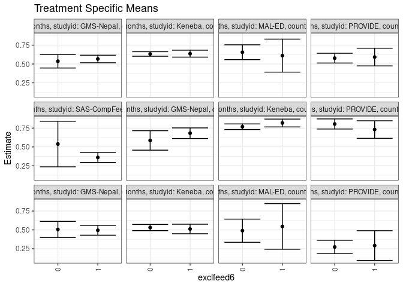

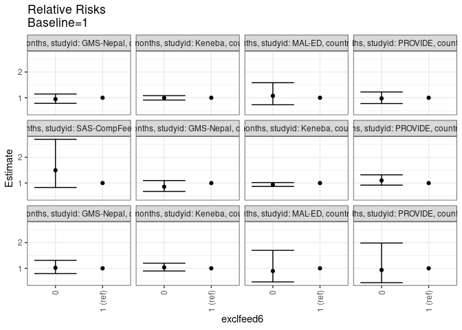

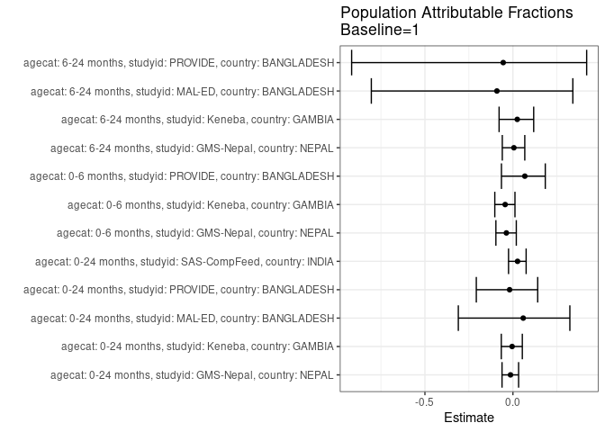

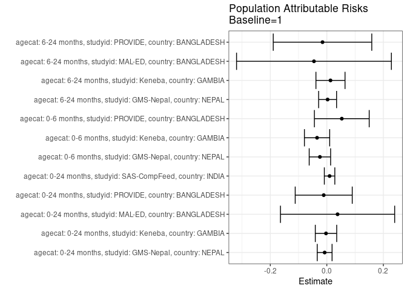

## Results Table

### Parameter: TSM

| agecat | studyid | country | intervention_level | baseline_level | estimate | ci_lower | ci_upper |
| --- | --- | --- | --- | --- | --- | --- | --- |
| 0-24 months | GMS-Nepal | NEPAL | 1 | NA | 0.5665914 | 0.5166081 | 0.6165747 |
| 0-24 months | GMS-Nepal | NEPAL | 0 | NA | 0.5364238 | 0.4464027 | 0.6264450 |
| 0-24 months | Keneba | GAMBIA | 1 | NA | 0.6370968 | 0.5912320 | 0.6829616 |
| 0-24 months | Keneba | GAMBIA | 0 | NA | 0.6329114 | 0.6028311 | 0.6629917 |
| 0-24 months | MAL-ED | BANGLADESH | 1 | NA | 0.6111111 | 0.3920367 | 0.8301855 |
| 0-24 months | MAL-ED | BANGLADESH | 0 | NA | 0.6562500 | 0.5578656 | 0.7546344 |
| 0-24 months | PROVIDE | BANGLADESH | 1 | NA | 0.5921053 | 0.4748033 | 0.7094072 |
| 0-24 months | PROVIDE | BANGLADESH | 0 | NA | 0.5775862 | 0.5129264 | 0.6422461 |
| 0-24 months | SAS-CompFeed | INDIA | 1 | NA | 0.3600000 | 0.2937351 | 0.4262649 |
| 0-24 months | SAS-CompFeed | INDIA | 0 | NA | 0.5384615 | 0.2364546 | 0.8404685 |
| 0-6 months | GMS-Nepal | NEPAL | 1 | NA | 0.6823529 | 0.6118839 | 0.7528220 |
| 0-6 months | GMS-Nepal | NEPAL | 0 | NA | 0.5862069 | 0.4571188 | 0.7152950 |
| 0-6 months | Keneba | GAMBIA | 1 | NA | 0.8177340 | 0.7659291 | 0.8695389 |
| 0-6 months | Keneba | GAMBIA | 0 | NA | 0.7684211 | 0.7311579 | 0.8056842 |
| 0-6 months | PROVIDE | BANGLADESH | 1 | NA | 0.7307692 | 0.6140851 | 0.8474534 |
| 0-6 months | PROVIDE | BANGLADESH | 0 | NA | 0.8045113 | 0.7374219 | 0.8716007 |
| 6-24 months | GMS-Nepal | NEPAL | 1 | NA | 0.4945055 | 0.4294359 | 0.5595751 |
| 6-24 months | GMS-Nepal | NEPAL | 0 | NA | 0.5053763 | 0.3987212 | 0.6120315 |
| 6-24 months | Keneba | GAMBIA | 1 | NA | 0.5119454 | 0.4487526 | 0.5751382 |
| 6-24 months | Keneba | GAMBIA | 0 | NA | 0.5309033 | 0.4898337 | 0.5719730 |
| 6-24 months | MAL-ED | BANGLADESH | 1 | NA | 0.5454545 | 0.2423555 | 0.8485536 |
| 6-24 months | MAL-ED | BANGLADESH | 0 | NA | 0.4888889 | 0.3352411 | 0.6425366 |
| 6-24 months | PROVIDE | BANGLADESH | 1 | NA | 0.2916667 | 0.0943448 | 0.4889886 |
| 6-24 months | PROVIDE | BANGLADESH | 0 | NA | 0.2727273 | 0.1836941 | 0.3617604 |

### Parameter: E(Y)

| agecat | studyid | country | intervention_level | baseline_level | estimate | ci_lower | ci_upper |
| --- | --- | --- | --- | --- | --- | --- | --- |
| 0-24 months | GMS-Nepal | NEPAL | NA | NA | 0.5589226 | 0.5151400 | 0.6027051 |
| 0-24 months | Keneba | GAMBIA | NA | NA | 0.6342072 | 0.6090524 | 0.6593621 |
| 0-24 months | MAL-ED | BANGLADESH | NA | NA | 0.6491228 | 0.5591034 | 0.7391422 |
| 0-24 months | PROVIDE | BANGLADESH | NA | NA | 0.5811688 | 0.5245443 | 0.6377934 |
| 0-24 months | SAS-CompFeed | INDIA | NA | NA | 0.3697479 | 0.3045176 | 0.4349782 |
| 0-6 months | GMS-Nepal | NEPAL | NA | NA | 0.6578947 | 0.5956613 | 0.7201282 |
| 0-6 months | Keneba | GAMBIA | NA | NA | 0.7831858 | 0.7527627 | 0.8136090 |
| 0-6 months | PROVIDE | BANGLADESH | NA | NA | 0.7837838 | 0.7252863 | 0.8422812 |
| 6-24 months | GMS-Nepal | NEPAL | NA | NA | 0.4972678 | 0.4417121 | 0.5528234 |
| 6-24 months | Keneba | GAMBIA | NA | NA | 0.5248918 | 0.4904236 | 0.5593599 |
| 6-24 months | MAL-ED | BANGLADESH | NA | NA | 0.5000000 | 0.3630175 | 0.6369825 |
| 6-24 months | PROVIDE | BANGLADESH | NA | NA | 0.2764228 | 0.1950773 | 0.3577682 |

### Parameter: RR

| agecat | studyid | country | intervention_level | baseline_level | estimate | ci_lower | ci_upper |
| --- | --- | --- | --- | --- | --- | --- | --- |
| 0-24 months | GMS-Nepal | NEPAL | 1 | 1 | 1.0000000 | 1.0000000 | 1.000000 |
| 0-24 months | GMS-Nepal | NEPAL | 0 | 1 | 0.9467560 | 0.7832370 | 1.144413 |
| 0-24 months | Keneba | GAMBIA | 1 | 1 | 1.0000000 | 1.0000000 | 1.000000 |
| 0-24 months | Keneba | GAMBIA | 0 | 1 | 0.9934305 | 0.9113118 | 1.082949 |
| 0-24 months | MAL-ED | BANGLADESH | 1 | 1 | 1.0000000 | 1.0000000 | 1.000000 |
| 0-24 months | MAL-ED | BANGLADESH | 0 | 1 | 1.0738636 | 0.7282183 | 1.583568 |
| 0-24 months | PROVIDE | BANGLADESH | 1 | 1 | 1.0000000 | 1.0000000 | 1.000000 |
| 0-24 months | PROVIDE | BANGLADESH | 0 | 1 | 0.9754789 | 0.7769013 | 1.224813 |
| 0-24 months | SAS-CompFeed | INDIA | 1 | 1 | 1.0000000 | 1.0000000 | 1.000000 |
| 0-24 months | SAS-CompFeed | INDIA | 0 | 1 | 1.4957265 | 0.8288715 | 2.699089 |
| 0-6 months | GMS-Nepal | NEPAL | 1 | 1 | 1.0000000 | 1.0000000 | 1.000000 |
| 0-6 months | GMS-Nepal | NEPAL | 0 | 1 | 0.8590963 | 0.6736130 | 1.095654 |
| 0-6 months | Keneba | GAMBIA | 1 | 1 | 1.0000000 | 1.0000000 | 1.000000 |
| 0-6 months | Keneba | GAMBIA | 0 | 1 | 0.9396956 | 0.8676281 | 1.017749 |
| 0-6 months | PROVIDE | BANGLADESH | 1 | 1 | 1.0000000 | 1.0000000 | 1.000000 |
| 0-6 months | PROVIDE | BANGLADESH | 0 | 1 | 1.1009102 | 0.9194229 | 1.318222 |
| 6-24 months | GMS-Nepal | NEPAL | 1 | 1 | 1.0000000 | 1.0000000 | 1.000000 |
| 6-24 months | GMS-Nepal | NEPAL | 0 | 1 | 1.0219833 | 0.7968052 | 1.310797 |
| 6-24 months | Keneba | GAMBIA | 1 | 1 | 1.0000000 | 1.0000000 | 1.000000 |
| 6-24 months | Keneba | GAMBIA | 0 | 1 | 1.0370312 | 0.8964221 | 1.199696 |
| 6-24 months | MAL-ED | BANGLADESH | 1 | 1 | 1.0000000 | 1.0000000 | 1.000000 |
| 6-24 months | MAL-ED | BANGLADESH | 0 | 1 | 0.8962963 | 0.4731967 | 1.697702 |
| 6-24 months | PROVIDE | BANGLADESH | 1 | 1 | 1.0000000 | 1.0000000 | 1.000000 |
| 6-24 months | PROVIDE | BANGLADESH | 0 | 1 | 0.9350649 | 0.4411401 | 1.982015 |

### Parameter: PAR

| agecat | studyid | country | intervention_level | baseline_level | estimate | ci_lower | ci_upper |
| --- | --- | --- | --- | --- | --- | --- | --- |
| 0-24 months | GMS-Nepal | NEPAL | 1 | NA | -0.0076689 | -0.0339330 | 0.0185953 |
| 0-24 months | Keneba | GAMBIA | 1 | NA | -0.0028895 | -0.0407593 | 0.0349802 |
| 0-24 months | MAL-ED | BANGLADESH | 1 | NA | 0.0380117 | -0.1640633 | 0.2400867 |
| 0-24 months | PROVIDE | BANGLADESH | 1 | NA | -0.0109364 | -0.1118324 | 0.0899596 |
| 0-24 months | SAS-CompFeed | INDIA | 1 | NA | 0.0097479 | -0.0087899 | 0.0282857 |
| 0-6 months | GMS-Nepal | NEPAL | 1 | NA | -0.0244582 | -0.0623411 | 0.0134247 |
| 0-6 months | Keneba | GAMBIA | 1 | NA | -0.0345481 | -0.0792460 | 0.0101497 |
| 0-6 months | PROVIDE | BANGLADESH | 1 | NA | 0.0530146 | -0.0439657 | 0.1499948 |
| 6-24 months | GMS-Nepal | NEPAL | 1 | NA | 0.0027623 | -0.0289795 | 0.0345040 |
| 6-24 months | Keneba | GAMBIA | 1 | NA | 0.0129464 | -0.0385156 | 0.0644084 |
| 6-24 months | MAL-ED | BANGLADESH | 1 | NA | -0.0454545 | -0.3193804 | 0.2284714 |
| 6-24 months | PROVIDE | BANGLADESH | 1 | NA | -0.0152439 | -0.1895523 | 0.1590645 |

### Parameter: PAF

| agecat | studyid | country | intervention_level | baseline_level | estimate | ci_lower | ci_upper |
| --- | --- | --- | --- | --- | --- | --- | --- |
| 0-24 months | GMS-Nepal | NEPAL | 1 | NA | -0.0137208 | -0.0618835 | 0.0322574 |
| 0-24 months | Keneba | GAMBIA | 1 | NA | -0.0045561 | -0.0660751 | 0.0534128 |
| 0-24 months | MAL-ED | BANGLADESH | 1 | NA | 0.0585586 | -0.3102443 | 0.3235521 |
| 0-24 months | PROVIDE | BANGLADESH | 1 | NA | -0.0188180 | -0.2080360 | 0.1407623 |
| 0-24 months | SAS-CompFeed | INDIA | 1 | NA | 0.0263636 | -0.0248925 | 0.0750564 |
| 0-6 months | GMS-Nepal | NEPAL | 1 | NA | -0.0371765 | -0.0967690 | 0.0191781 |
| 0-6 months | Keneba | GAMBIA | 1 | NA | -0.0441123 | -0.1029591 | 0.0115948 |
| 0-6 months | PROVIDE | BANGLADESH | 1 | NA | 0.0676393 | -0.0651972 | 0.1839102 |
| 6-24 months | GMS-Nepal | NEPAL | 1 | NA | 0.0055549 | -0.0604002 | 0.0674077 |
| 6-24 months | Keneba | GAMBIA | 1 | NA | 0.0246649 | -0.0785693 | 0.1180180 |
| 6-24 months | MAL-ED | BANGLADESH | 1 | NA | -0.0909091 | -0.8045548 | 0.3405118 |
| 6-24 months | PROVIDE | BANGLADESH | 1 | NA | -0.0551471 | -0.9164156 | 0.4190533 |